# Data Analysis Skill Test - Case 1

## **Análise Exploratória**

Data summary

| Name | data |
| --- | --- |
| Number of rows | 186 |
| Number of columns | 3 |
| _______________________ |  |
| Column type frequency: |  |
| character | 2 |
| numeric | 1 |
| ________________________ |  |
| Group variables | None |

**Variable type: character**

| skim_variable | n_missing | complete_rate | min | max | empty | n_unique | whitespace |
| --- | --- | --- | --- | --- | --- | --- | --- |
| isocode | 0 | 1 | 3 | 3 | 0 | 3 | 0 |
| year | 0 | 1 | 4 | 4 | 0 | 62 | 0 |

**Variable type: numeric**

| skim_variable | n_missing | complete_rate | mean | sd | p0 | p25 | p50 | p75 | p100 | hist |
| --- | --- | --- | --- | --- | --- | --- | --- | --- | --- | --- |
| rtfpna | 0 | 1 | 0.98 | 0.18 | 0.62 | 0.86 | 1 | 1.05 | 1.38 | ▃▂▇▂▂ |

Na variável isocode temos 186 registros, sendo 3 valores únicos - CAN, MEX e USA. Nenhum missing value.

```
## CAN MEX USA
##  62  62  62
```

Gráfico de histograma e densidade para verificar a distribuição da variável rtfpna

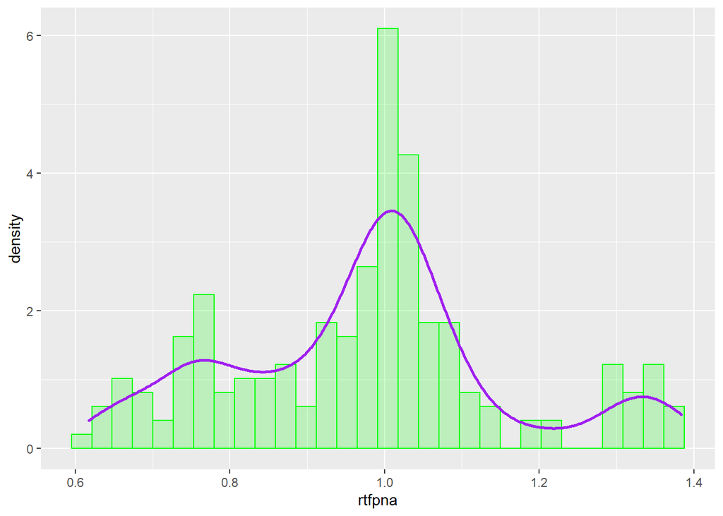

Gráfico boxplot para verificar a distribuição da variável rtfpna por isocode

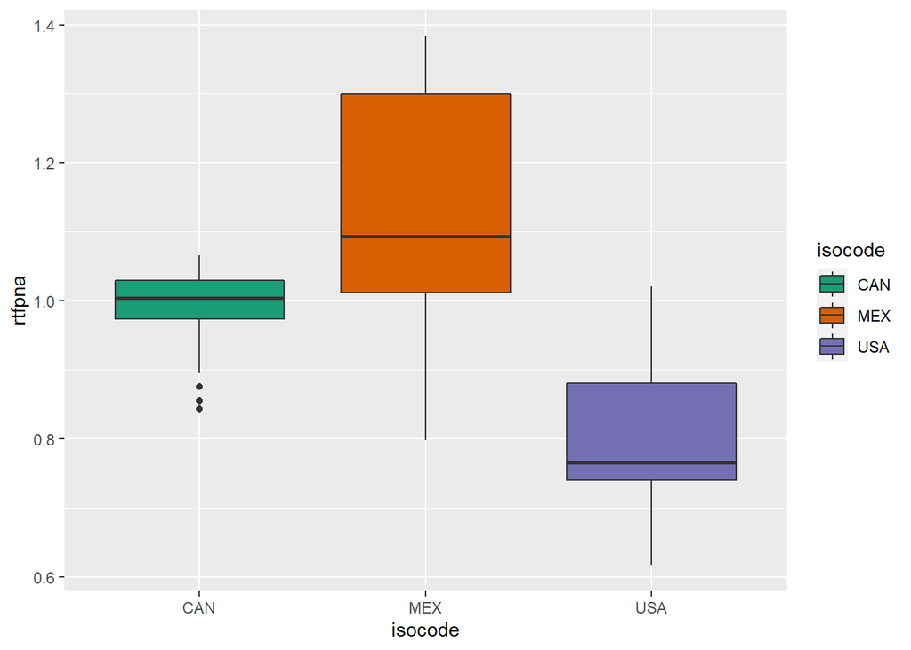

### Série temporal para USA

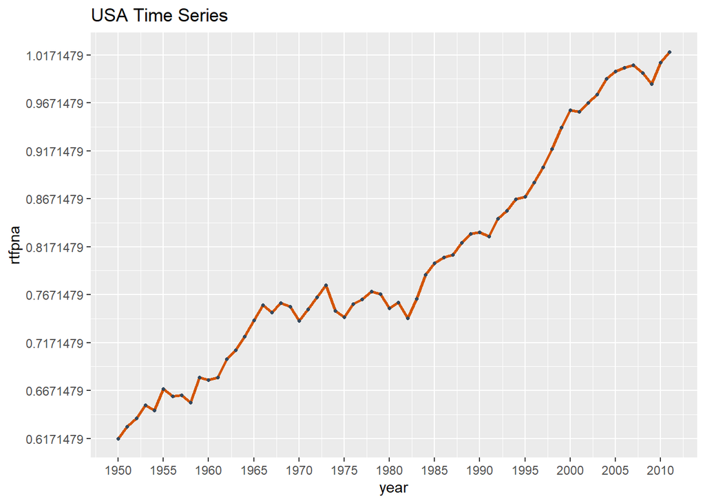

### Série temporal para CAN

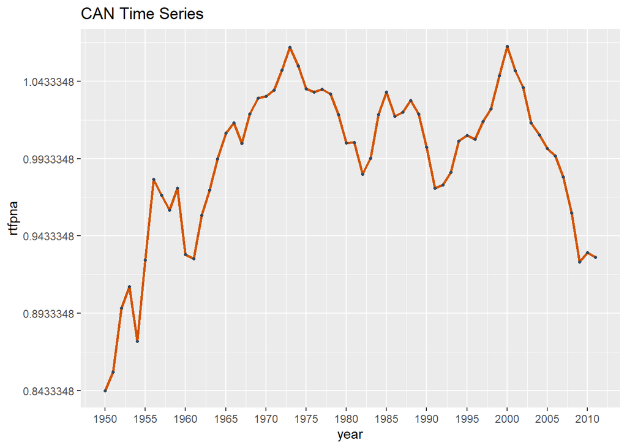

### Série temporal para MEX

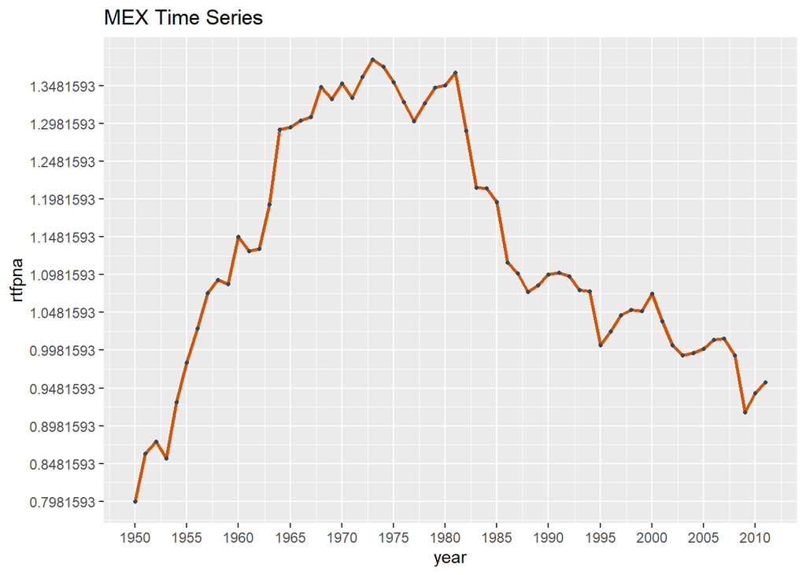

## **Previsão da Série Temporal**

Irei utilizar modelagem automática ARIMA

##### USA

Prevendo RTFPNA para os próximos 10 anos

Resultado sumarizado para USA:

```
## Series: data$rtfpna[data$isocode == "USA"]
## ARIMA(0,1,0) with drift
##
## Coefficients:
##        drift
##       0.0066
## s.e.  0.0014
##
## sigma^2 estimated as 0.0001291:  log likelihood=187.09
## AIC=-370.17   AICc=-369.97   BIC=-365.95
##
## Training set error measures:
##                        ME       RMSE         MAE         MPE     MAPE     MASE
## Training set 9.847371e-06 0.01117543 0.009022366 -0.02282104 1.154826 0.799736
##                    ACF1
## Training set 0.03225483
```

Método utilizado pelo ARIMA automático:

```
## [1] "ARIMA(0,1,0) with drift"
```

Forecast do modelo

```
##    Point Forecast    Lo 80    Hi 80    Lo 95    Hi 95
## 63       1.027002 1.012444 1.041561 1.004737 1.049268
## 64       1.033613 1.013024 1.054202 1.002125 1.065101
## 65       1.040223 1.015007 1.065440 1.001659 1.078788
## 66       1.046834 1.017717 1.075951 1.002303 1.091365
## 67       1.053445 1.020891 1.085999 1.003657 1.103232
## 68       1.060055 1.024394 1.095716 1.005516 1.114594
## 69       1.066666 1.028147 1.105184 1.007757 1.125575
## 70       1.073276 1.032098 1.114454 1.010300 1.136253
## 71       1.079887 1.036211 1.123563 1.013090 1.146683
## 72       1.086497 1.040459 1.132536 1.016088 1.156907
```

Plotando a previsão na série temporal junto com intervalo de confiança de 80% e 95%

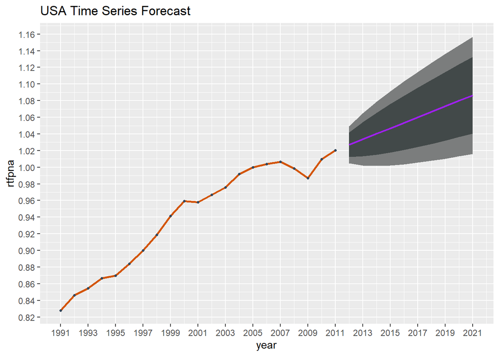

##### CAN

Prevendo RTFPNA para os próximos 10 anos

Resultado sumarizado para CAN:

```
## Series: data$rtfpna[data$isocode == "CAN"]
## ARIMA(0,2,3)
##
## Coefficients:
##           ma1      ma2     ma3
##       -0.6432  -0.4813  0.2222
## s.e.   0.1267   0.1267  0.1163
##
## sigma^2 estimated as 0.0003356:  log likelihood=155.45
## AIC=-302.91   AICc=-302.18   BIC=-294.53
##
## Training set error measures:
##                        ME       RMSE        MAE        MPE    MAPE      MASE
## Training set -0.003392639 0.01756456 0.01330863 -0.3506198 1.36017 0.8848314
##                     ACF1
## Training set -0.03721486
```

Método utilizado pelo ARIMA automático:

```
## [1] "ARIMA(0,2,3)"
```

Forecast do modelo

```
##    Point Forecast     Lo 80     Hi 80     Lo 95     Hi 95
## 63      0.9171747 0.8936983 0.9406512 0.8812706 0.9530788
## 64      0.9123099 0.8727405 0.9518792 0.8517937 0.9728260
## 65      0.9057691 0.8567515 0.9547866 0.8308031 0.9807350
## 66      0.8992282 0.8411095 0.9573470 0.8103433 0.9881132
## 67      0.8926874 0.8255945 0.9597804 0.7900776 0.9952973
## 68      0.8861466 0.8100921 0.9622012 0.7698312 1.0024621
## 69      0.8796058 0.7945364 0.9646753 0.7495033 1.0097084
## 70      0.8730650 0.7788867 0.9672434 0.7290317 1.0170984
## 71      0.8665242 0.7631170 0.9699315 0.7083765 1.0246720
## 72      0.8599834 0.7472099 0.9727569 0.6875112 1.0324556
```

Plotando a previsão na série temporal junto com intervalo de confiança de 80% e 95%

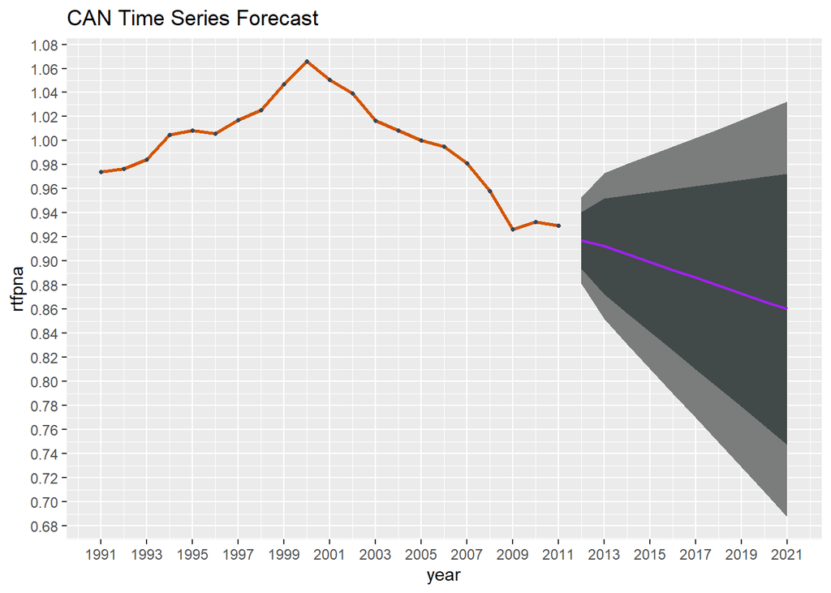

##### MEX

Prevendo RTFPNA para os próximos 10 anos

Resultado sumarizado para MEX:

```
## Series: data$rtfpna[data$isocode == "MEX"]
## ARIMA(0,2,1)
##
## Coefficients:
##           ma1
##       -0.8502
## s.e.   0.0617
##
## sigma^2 estimated as 0.001167:  log likelihood=117.33
## AIC=-230.65   AICc=-230.44   BIC=-226.46
##
## Training set error measures:
##                        ME       RMSE        MAE        MPE     MAPE     MASE
## Training set -0.004967013 0.03332467 0.02664148 -0.4162653 2.396274 1.004223
##                    ACF1
## Training set 0.04940407
```

Método utilizado pelo ARIMA automático:

```
## [1] "ARIMA(0,2,1)"
```

Forecast do modelo

```
##    Point Forecast     Lo 80     Hi 80     Lo 95    Hi 95
## 63      0.9494087 0.9056291 0.9931883 0.8824535 1.016364
## 64      0.9430517 0.8763397 1.0097637 0.8410245 1.045079
## 65      0.9366947 0.8490163 1.0243731 0.8026021 1.070787
## 66      0.9303377 0.8221078 1.0385676 0.7648143 1.095861
## 67      0.9239807 0.7950811 1.0528803 0.7268458 1.121116
## 68      0.9176237 0.7676980 1.0675494 0.6883322 1.146915
## 69      0.9112667 0.7398389 1.0826946 0.6490905 1.173443
## 70      0.9049097 0.7114401 1.0983794 0.6090234 1.200796
## 71      0.8985527 0.6824678 1.1146377 0.5680793 1.229026
## 72      0.8921958 0.6529048 1.1314867 0.5262319 1.258160
```

Plotando a previsão na série temporal junto com intervalo de confiança de 80% e 95%

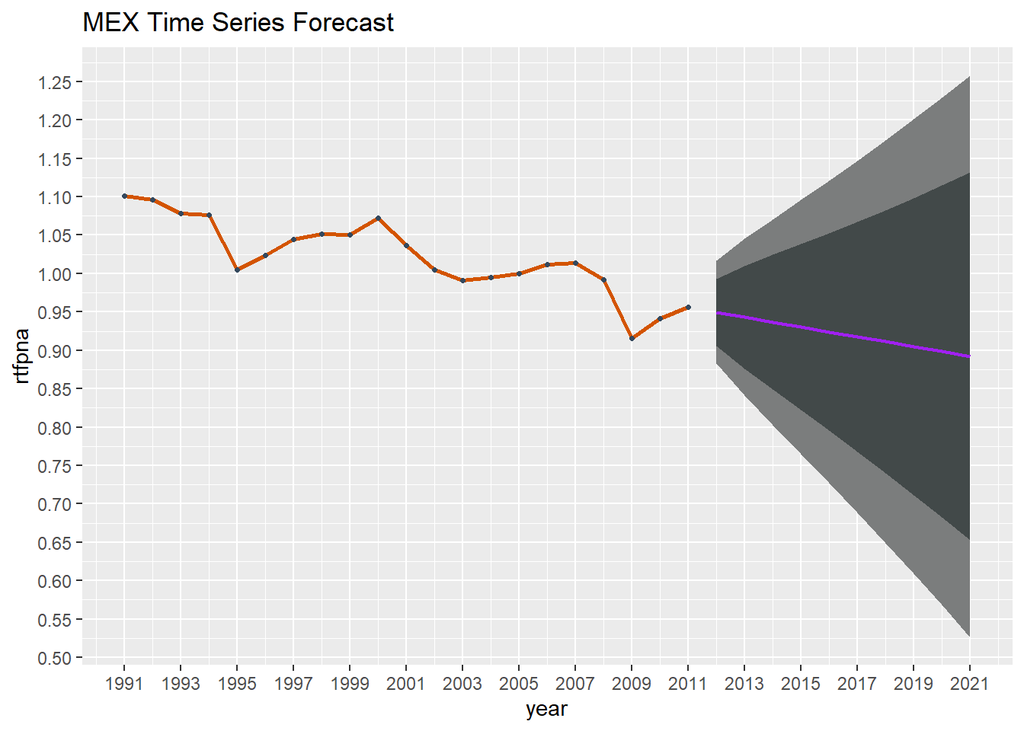

##### Can you think about another feature that could be helpful in explaining TFP series? Explain.

Pode haver correlação entre o PIB - Produto Interno Bruto de um país com seus respectivo TFP - Produtividade Total dos Fatores

Por mais que o PIB não avalie diretamente a eficiência que uma economia combina a totalidade de seus recursos para gerar produto, pode haver correlação entre esta eficiência junto com a soma de todos os bens e serviços produzidos num país em um determinado período.